# Anova

#### Between groups

**First load packages and library**  
> point and click on the folder under the Environment Tab

**Install packages if you have not installed them**

```r
install.packages(c("tidyverse", "lsr", "multcomp"))
```

**Load them**

```r
library(tidyverse)
library(lsr)
library(multcomp)
```

Factor levels for `flavor` because ‘1’ flavor does not make sense. Recode variables into a new variable instead of overwriting the original codes. Now codes like ‘1’ are salty while ‘2’ is sweet.

```r
class$flavortown[class$Flavor==1] <- "salty"
class$flavortown[class$Flavor==2] <- "sweet"
class$flavortown[class$Flavor==3] <- "savory"
```

Alternatively, another `recode_factor` function comes from the `tidyverse` package and expedites the factoring process.

```r
class$flavortown <- recode_factor(class$Flavor, `1` = "salty", `2` = "sweet", `3` = "savory")
```

**Analysis**  
Next is the creation of the actual model with `flavor` against `exercise` and the data is from the `class` datafile.

```r
flavorlandaov <- aov(exercise~flavortown, data = class)
```

**Results**  
We want to find the results of the analysis of variance.

```r
summary(flavorlandaov)
```

```
##             Df Sum Sq Mean Sq F value Pr(>F)
## flavortown   2  411.5  205.74    3.73 0.0332 *
## Residuals   38 2096.0   55.16
## ---
## Signif. codes:  0 '***' 0.001 '**' 0.01 '*' 0.05 '.' 0.1 ' ' 1
```

**Tukey tests**  
Now that we know there are a difference between the groups of `flavor`, we have to find out which groups actually excercise more. a *Tukey* test is an analysis that provides a more in-depth look at the differences between the means while dictating which relations are statistically significant or not.  
The `glht` function comes from the `multcomp` package. This is a general linear hypothesis test.  
**Analysis**

```r
tukey <- glht(flavorlandaov,linfct=mcp(flavortown = "Tukey"))
```

**Results**

```r
summary(tukey)
```

```
##
##   Simultaneous Tests for General Linear Hypotheses
##
## Multiple Comparisons of Means: Tukey Contrasts
##
##
## Fit: aov(formula = exercise ~ flavortown, data = class)
##
## Linear Hypotheses:
##                      Estimate Std. Error t value Pr(>|t|)
## sweet - salty == 0  -10.72222    4.10537  -2.612   0.0319 *
## savory - salty == 0 -10.63158    4.08568  -2.602   0.0326 *
## savory - sweet == 0   0.09064    2.44284   0.037   0.9992
## ---
## Signif. codes:  0 '***' 0.001 '**' 0.01 '*' 0.05 '.' 0.1 ' ' 1
## (Adjusted p values reported -- single-step method)
```

We can look at the *p*-values which tells us that there is a difference between reported exercise amounts of the `sweet-salty` and the `savory-salt` relationship.

**Information for write up**  
We will need some more information for the write up, specifically the sample size, means, standard deviations and effect size.  
**Means and Standard Deviation**  
This can be done with the `tapply` function. The command requests that the `sd` or `mean` function be applied to `class$exercise` and `class$flavor`.

```r
tapply(class$exercise,class$flavortown, sd)
```

```
##     salty     sweet    savory
## 16.103830  5.333640  6.808577
```

```r
tapply(class$exercise,class$flavortown, mean)
```

```
##     salty     sweet    savory
## 18.000000  7.277778  7.368421
```

**Sample size**  
Then we will need to know the sample size per group. This will be accomplished with the `table` function.

```r
table(class$flavortown)
```

```
##
##  salty  sweet savory
##      4     18     19
```

**Effect size**  
Effect sizes can be found from the `lsr` package utilizing the `etaSquared` function.

```r
etaSquared(flavorlandaov)
```

```
##               eta.sq eta.sq.part
## flavortown 0.1640989   0.1640989
```

| Table 1 |  |  |  |
| --- | --- | --- | --- |
| *Summary Statistics* |  |  |  |
| Variable | *M* | *SD* | n |
| Salty | 18.00 | 16.10 | 4 |
| Sweet | 7.28 | 5.33 | 18.00 |
| Savory | 7.37 | 6.81 | 19.00 |

**Plots**  
Usually information can be provided with plots which can easy cognitive loads by visually presenting information.  
This is done with the `barplot` function.  
First a model of what you want to plot has to be created. I named my model `saltyfitness`.

```r
saltyfitness <- tapply(class$exercise,class$flavortown, mean)
```

Then `saltyfitness` can be wrapped with a barplot. Further parameters can be added, such as `xlab` which is a label for the axis or `ylab` which is the y axis label. Things like color or border can be added as well.

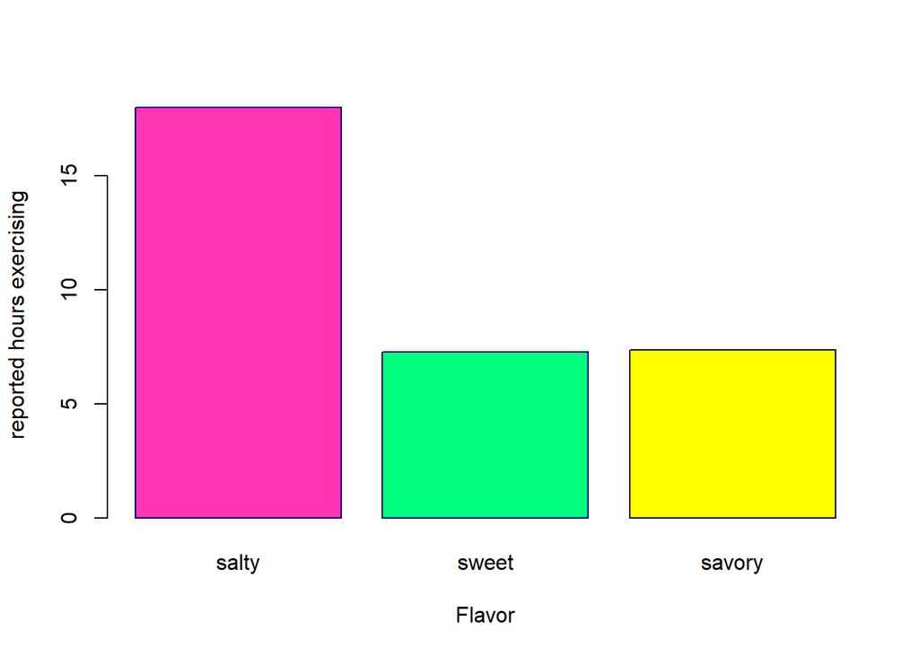

```r
barplot(saltyfitness, xlab = "Flavor", ylab = "reported hours exercising", col = c("maroon1","springgreen1","yellow"),border = "navyblue" )
```